# *hespresso*: 2. Case Studies

## 1.1 HOBIT

HOBIT (Sun, Sese, and Shimizu 2025) can be executed using the `hobit()` function, which performs a statistical test to detect homeologs with shifts in expression ratios, referred to as **ratio-shifted homeologs** (**RSHs**), between wet and dry habitats.

```r
x_output <- hobit(x)
```

```r
head(x_output)
```

```
##          gene    pvalue qvalue raw_pvalue raw_qvalue      Dmax    ORmax
## 1 CARHR005580 0.8507673      1  0.8220229  1.0000000 0.0545450 1.263108
## 2 CARHR006420 0.8321699      1  0.7999778  1.0000000 0.0642100 1.295740
## 3 CARHR010700 0.2112504      1  0.1349952  0.8999683 0.1124405 6.044481
## 4 CARHR012530 0.4896505      1  0.4087959  1.0000000 0.1086330 1.553849
## 5 CARHR013180 1.0000000      1  1.0000000  1.0000000 0.0113280 1.046862
## 6 CARHR013900 0.9157449      1  0.8993432  1.0000000 0.0025505 1.139030
##   theta__C_hirsuta__dry theta__C_amara__dry theta__C_hirsuta__wet
## 1             0.3591115           0.6408885             0.4146560
## 2             0.5578275           0.4421725             0.4942690
## 3             0.8489735           0.1510265             0.9708220
## 4             0.4622880           0.5377120             0.5725410
## 5             0.5369170           0.4630830             0.5494805
## 6             0.0268173           0.9731830             0.0314679
##   theta__C_amara__wet theta0__C_hirsuta theta0__C_amara logLik_H1 logLik_H0
## 1          0.58534400        0.38770250       0.6122975 -54.22255 -54.18235
## 2          0.50573100        0.52606550       0.4739345 -49.37455 -49.27290
## 3          0.02917775        0.90239650       0.0976038 -19.65035 -20.96430
## 4          0.42745900        0.51738000       0.4826200 -62.82985 -63.23330
## 5          0.45051950        0.54327150       0.4567285 -56.71935 -56.43760
## 6          0.96853200        0.03611595       0.9638840 -18.50160 -18.54310
```

```r
head(x_output[order(x_output$pvalue), ])
```

```
##           gene       pvalue       qvalue   raw_pvalue   raw_qvalue      Dmax
## 29 CARHR069310 4.154296e-13 4.154296e-11 4.367209e-18 4.367209e-16 0.6976665
## 30 CARHR073240 1.007566e-02 3.754734e-01 2.093724e-03 8.146894e-02 0.4360225
## 61 CARHR134950 1.126420e-02 3.754734e-01 2.444068e-03 8.146894e-02 0.1337805
## 89 CARHR193560 1.589850e-02 3.974625e-01 3.939918e-03 9.849795e-02 0.5854550
## 54 CARHR123010 2.158427e-02 4.202553e-01 6.013009e-03 1.202602e-01 0.0745760
## 96 CARHR209790 2.521532e-02 4.202553e-01 7.452642e-03 1.242107e-01 0.3137325
##        ORmax theta__C_hirsuta__dry theta__C_amara__dry theta__C_hirsuta__wet
## 29 34.304546             0.1876975           0.8123025            0.88823200
## 30  7.730490             0.8236615           0.1763385            0.37761100
## 61  2.107090             0.3151260           0.6848740            0.17818150
## 89 32.233836             0.3194225           0.6805775            0.93317900
## 54  3.625798             0.1075130           0.8924870            0.03253510
## 96 18.858472             0.3559585           0.6440415            0.02939535
##    theta__C_amara__wet theta0__C_hirsuta theta0__C_amara  logLik_H1  logLik_H0
## 29          0.11176800         0.5372500       0.4627500 -102.12550 -139.44650
## 30          0.62238900         0.5969910       0.4030090  -29.38350  -33.96035
## 61          0.82181850         0.2472540       0.7527460 -106.47200 -110.91500
## 89          0.06682065         0.6162845       0.3837155  -13.84400  -17.81460
## 54          0.96746500         0.0717532       0.9282470  -48.46885  -52.16130
## 96          0.97060450         0.2000810       0.7999190  -19.17665  -22.86625
```

To visualize homeologs with HER shifts between wet and dry habitats, use the `plot_HER()` function. This function creates a scatter plot of HERs calculated from the wet and dry groups. By default, HER is defined as the expression ratio of the first subgenome (i.e., the subgenome derived from *C. hirsuta*) relative to the total expression across all subgenomes. In the example below, homeologs with *p*-values less than 0.05 are highlighted.

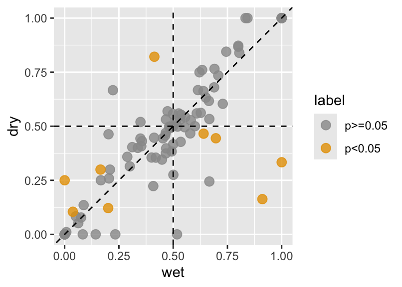

Figure 2: Changes in Homeolog Expression Ratios Between Wet and Dry Habitats  
Each point represents the homeolog expression ratio in wet (x-axis) and dry (y-axis) habitats. Orange points indicate homeologs with significant changes in expression ratios between the two conditions, as detected by HOBIT, while gray points represent those without significant changes.

```r
is_sig <- ifelse(x_output$pvalue < 0.05, "p<0.05", "p>=0.05")
plot_HER(x, label = is_sig)
```

Note that, for actual studies, a more stringent threshold such as *q*-value <0.01 is recommended.

## 1.2 HomeoRoq

For allopolyploids composed of two subgenomes under two different conditions, HomeoRoq (Akama et al. 2014) is also a one of choices for detecting RSHs. It can be executed using the `homeoroq()` function as shown below.

```r
x_homeoroq <- homeoroq(x)
```

```r
head(x_homeoroq[order(x_homeoroq$pvalue), ])
```

```
##           gene   pvalue   qvalue sumexp__wet__C_hirsuta sumexp__wet__C_amara
## 29 CARHR069310 0.000000 0.000000             2468.82415            307.48515
## 89 CARHR193560 0.002500 0.125000               11.18187              0.00000
## 84 CARHR188200 0.009600 0.320000              702.18829            344.70747
## 43 CARHR099990 0.014175 0.354375              176.65473             81.25169
## 15 CARHR026740 0.018150 0.362500              286.70212            527.22162
## 30 CARHR073240 0.021750 0.362500               20.90714             33.36600
##    sumexp__dry__C_hirsuta sumexp__dry__C_amara ratio__wet__C_hirsuta
## 29              23.948331           102.231779             0.8892468
## 89               1.462438             3.721857             1.0000000
## 84             687.949865           790.651961             0.6707337
## 43             152.405018           192.779205             0.6849567
## 15             451.963487           417.041454             0.3522469
## 30              23.960320             4.700728             0.3852208
##    ratio__dry__C_hirsuta   ratio_sd
## 29            0.07225683 0.38755180
## 89            1.00000000 0.46206978
## 84            0.66619375 0.12244227
## 43            0.65226041 0.13659535
## 15            0.46157104 0.09024708
## 30            0.41796367 0.22645822
```

The overlap of RSHs detected by HOBIT and HomeoRoq can be visualized using an UpSet plot, implemented in the UpSetR package.

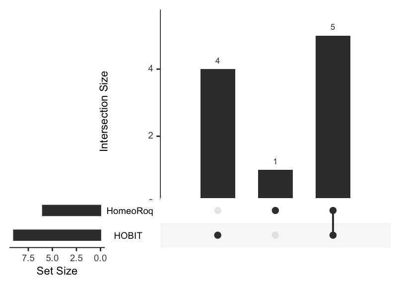

Figure 3: Overlap of ratio-shifted Homeologs Detected by HOBIT and HomeoRoq

```r
library("UpSetR")
sig_homeologs <- list(
    HOBIT = x_output$gene[x_output$pvalue < 0.05],
    HomeoRoq = x_homeoroq$gene[x_homeoroq$pvalue < 0.05]
)

upset(fromList(sig_homeologs))
```

Additionally, RSHs detected by both methods can be visualized using the `plot_HER()` function.

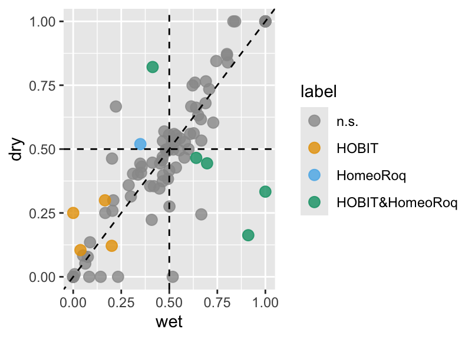

Figure 4: Comparison of Ratio-Shifted Homeologs Detection by HOBIT and HomeoRoq  
Each point represents the homeolog expression ratio in wet (x-axis) and dry (y-axis) habitats. Points labeled with n.s. represent homeologs without significant changes detected by either method, while other points represent ratio-shifted homeologs detected by the corresponding methods.

```r
is_sig <- rep("n.s.", length = nrow(x_output))
is_sig[x_output$pvalue < 0.05] <- "HOBIT"
is_sig[x_homeoroq$pvalue < 0.05] <- "HomeoRoq"
is_sig[x_output$pvalue < 0.05 & x_homeoroq$pvalue < 0.05] <- "HOBIT&HomeoRoq"
is_sig <- factor(is_sig, levels = c("n.s.", "HOBIT", "HomeoRoq", "HOBIT&HomeoRoq"))
plot_HER(x, label = is_sig)
```

# 2 Case Study for Allotriploid *C. insueta*

Allotriploid *Cardamine insueta* (2n = 3x = 24, RRA) serves as an example of uneven subgenome composition. Two of its subgenomes are derived from *Cardamine rivularis* (2n = 2x = 16, RR), a species inhabiting grassy areas away from riversides. The third subgenome comes from *Cardamine amara* (2n = 2x = 16, AA), a species typically found on riversides or in streams. RNA-Seq studies on *C. insueta* leaflets floating on water suggested that *C. insueta* shifts HERs over time following submergence (Sun et al. 2020).

Here, we demonstrate how to detect RSHs across time points using HOBIT, similar to ANOVA. We use a sample dataset that includes 100 homeologs randomly selected from the original experiment. The data spans nine time points following leaf submergence and can be loaded with the following code.

```r
gexp <- read.table(system.file(package = "hespresso", "extdata", "C_insueta.tsv.gz"),
                   header = TRUE, sep = "\t", row.names = 1)
head(gexp)
```

```
##               T00 T02 T04 T08 T12 T24 T48 T72 T96
## CARHR005230_R  21   5   9  19  29   8  20  19  11
## CARHR005930_R   0   0   1   2   6   0   0   0   1
## CARHR009830_R  44  11  28  35  73  18  72  49  35
## CARHR011390_R  59  20  24  14   2   8  14   8   6
## CARHR011970_R 700 183 537 307 584 278 572 500 282
## CARHR012630_R 214 183 216 203 499 186 218 181 171
```

```r
group <- c("T00", "T02", "T04", "T08", "T12", "T24", "T48", "T72", "T96")
```

Next, load the homeolog mapping table, which links gene expression values to their corresponding homeologs. This file is tab-separated, with the first and second columns representing genes from *C. rivularis* and *C. amara*, respectively.

```r
mapping_table <- read.table(system.file(package = "hespresso", "extdata", "C_insueta.homeolog.tsv.gz"),
                            header = TRUE, sep = "\t")
head(mapping_table)
```

```
##     C_rivularis       C_amara
## 1 CARHR005230_R CARHR005230_A
## 2 CARHR005930_R CARHR005930_A
## 3 CARHR009830_R CARHR009830_A
## 4 CARHR011390_R CARHR011390_A
## 5 CARHR011970_R CARHR011970_A
## 6 CARHR012630_R CARHR012630_A
```

Use the `newExpMX()` function to create a homeolog expression matrix from the gene expression data (`gexp`) and mapping table (`mapping_table`). The result is stored as an `ExpMX` class object.

```r
x <- newExpMX(gexp, group, mapping_table)
x
```

```
## # 2 subgenomes (C_rivularis, C_amara)
## # 100 homeologs
## ---------------------
## Experiment Design:
##   group
## 1   T00
## 2   T02
## 3   T04
## 4   T08
## 5   T12
## 6   T24
## 7   T48
## 8   T72
## 9   T96
## ---------------------
## > subgenome: C_rivularis
##      [,1] [,2] [,3] [,4] [,5] [,6] [,7] [,8] [,9]
## [1,]   21    5    9   19   29    8   20   19   11
## [2,]    0    0    1    2    6    0    0    0    1
## [3,]   44   11   28   35   73   18   72   49   35
## [4,]   59   20   24   14    2    8   14    8    6
## [5,]  700  183  537  307  584  278  572  500  282
## [6,]  214  183  216  203  499  186  218  181  171
## +++++++++++++++++++++
## > subgenome: C_amara
##      [,1] [,2] [,3] [,4] [,5] [,6] [,7] [,8] [,9]
## [1,]    1    0    0    5    3    1    2    4    2
## [2,]    0    0    0    0    0    0    0    0    0
## [3,]   18    4   13   15   11   20   30   20   24
## [4,]    0    0    0    0    0    0    0    0    0
## [5,]  225   70  187   71  156   82  202  205  101
## [6,]   95   48   69   78  156   53   93   50   46
## ---------------------
```

Normalize the read counts using the TMM method (Robinson and Oshlack 2010), since the data has not been normalized.

```r
x <- norm_counts(x)
```

User can visualize the HER distribution using the `plot_HER_distr` function. By default, HER is calculated as the expression ratio of the first subgenome across all subgenomes, where the first subgenome corresponds to *C. rivularis* as it listed in the first column of the mapping table (`mapping_table`). The `plot_HER_distr()` function to generate a histogram for each time point.

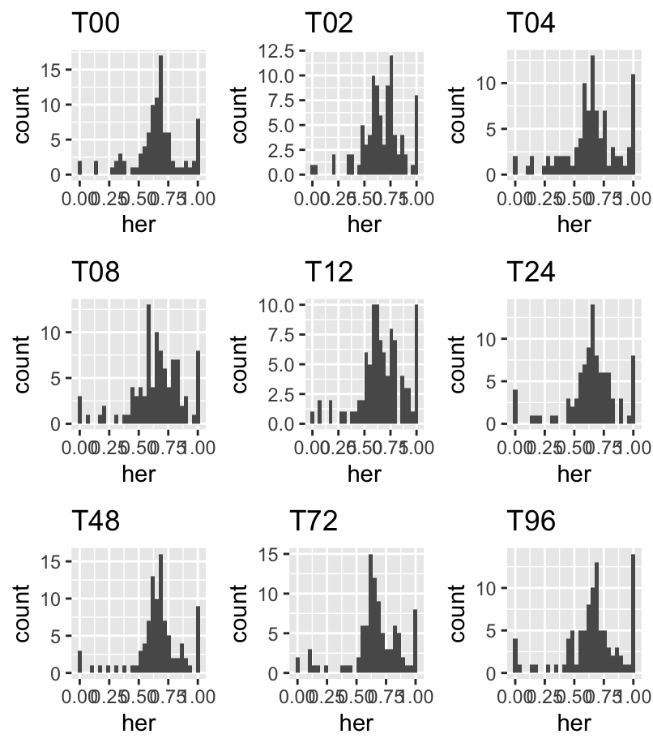

Figure 5: Distribution of Homeolog Expression Ratios  
Histograms display the distributions of homeolog expression ratios in *C. insueta* across nine time points following leaf submergence in water.

```r
distr_plots <- plot_HER_distr(x)

library(ggplot2)
library(gridExtra)
distr_plots <- lapply(seq_along(distr_plots), function(p) {
    distr_plots[[p]] + ggtitle(names(distr_plots)[p])
})
grid.arrange(grobs = distr_plots, ncol = 3)
```

These visualizations show that most homeologs in *C. insueta* are expressed with a 2 to 1 ratio between the *C. rivularis* and *C. amara* subgenomes, as the histogram peaks are centered around two-thirds.

Now apply the `hobit()` function to detect homeologs with differential HERs across the nine time points following leaf submergence. Note that, since this dataset has only one replicate per condition, we set `no_replicate = TRUE` to avoid errors arising from dispersion estimation, which requires multiple replicates.

```r
x_output <- hobit(x, no_replicate = TRUE)
```

```r
head(x_output)
```

```
##            gene    pvalue qvalue raw_pvalue raw_qvalue      Dmax     ORmax
## 1 CARHR005230_R 0.7727031      1  0.7727031          1 0.1928445  4.567933
## 2 CARHR005930_R 0.6505253      1  0.6505253          1 0.1990117  4.287255
## 3 CARHR009830_R 0.9999886      1  0.9999886          1 0.3553730  5.914587
## 4 CARHR011390_R 0.1533584      1  0.1533584          1 0.2409471 15.010827
## 5 CARHR011970_R 1.0000000      1  1.0000000          1 0.1011605  1.760697
## 6 CARHR012630_R 1.0000000      1  1.0000000          1 0.0886765  1.641054
##   theta__C_rivularis__T00 theta__C_amara__T00 theta__C_rivularis__T02
## 1                0.894351           0.1056490               0.8863770
## 2                0.596326           0.4036740               0.5935485
## 3                0.670461           0.3295390               0.7072350
## 4                0.962427           0.0375729               0.9698845
## 5                0.744600           0.2554000               0.7135620
## 6                0.686183           0.3138170               0.7782100
##   theta__C_amara__T02 theta__C_rivularis__T04 theta__C_amara__T04
```

[output cut: 41 more lines]

# 3 Case Study for Allohexaploid *T. aestivum* (Bread Wheat)

Bread wheat, *Triticum aestivum*, is one of the world’s most important crops and also serves as a model for studying allopolyploid species. It originated through hybridization among three diploid progenitor species and contains three distinct types of subgenomes. To demonstrate the applicability of HOBIT to allohexaploid species, we present a case study using wheat RNA-Seq data to detect homeologs with shifting HERs between two tissues, shoot apex and leaf (Yang et al. 2021).

In this example, 100 homeologs were randomly selected from the original dataset. The expression data can be loaded using the following code.

```r
gexp <- read.table(system.file(package = "hespresso", "extdata", "T_aestivum.tsv.gz"),
                   header = TRUE, sep = "\t", row.names = 1)
head(gexp)
```

```
##                    apex_1 apex_2 apex_3 leaf_1 leaf_2 leaf_3
## TraesCS1A02G122700    991    969   1020    375    350    474
## TraesCS1A02G134600    124    168    164     92     68    137
## TraesCS1A02G196500      0      5      2    112    218    125
## TraesCS1A02G218900    228    137    104    123    177    232
## TraesCS1A02G227600    725    736    637    342    343    400
## TraesCS1A02G238800    411      7      1     35    202     19
```

```r
group <- c("apex", "apex", "apex", "leaf", "leaf", "leaf")
```

Next, load the mapping table that links each gene to its corresponding homeologs. Since wheat has three subgenomes, this table contains three columns, each representing one subgenome.

```r
mapping_table <- read.table(system.file(package = "hespresso", "extdata", "T_aestivum.homeolog.tsv.gz"),
                            header = TRUE, sep = "\t")
head(mapping_table)
```

```
##                    A                  B                  D
## 1 TraesCS1A02G122700 TraesCS1B02G141900 TraesCS1D02G123600
## 2 TraesCS1A02G134600 TraesCS1B02G148200 TraesCS1D02G131100
## 3 TraesCS1A02G196500 TraesCS1B02G211100 TraesCS1D02G200000
## 4 TraesCS1A02G218900 TraesCS1B02G232400 TraesCS1D02G220600
## 5 TraesCS1A02G227600 TraesCS1B02G241900 TraesCS1D02G229300
## 6 TraesCS1A02G238800 TraesCS1B02G250900 TraesCS1D02G239000
```

We then construct an `ExpMX` class object using the `newExpMX()` function. This converts the gene expression matrix (`gexp`) into a homeolog expression matrix based on the mapping table (`mapping_table`).

```r
x <- newExpMX(gexp, group, mapping_table)
x
```

```
## # 3 subgenomes (A, B, D)
## # 100 homeologs
## ---------------------
## Experiment Design:
##   group
## 1  apex
## 2  apex
## 3  apex
## 4  leaf
## 5  leaf
## 6  leaf
## ---------------------
## > subgenome: A
##      [,1] [,2] [,3] [,4] [,5] [,6]
## [1,]  991  969 1020  375  350  474
## [2,]  124  168  164   92   68  137
## [3,]    0    5    2  112  218  125
## [4,]  228  137  104  123  177  232
## [5,]  725  736  637  342  343  400
## [6,]  411    7    1   35  202   19
## +++++++++++++++++++++
## > subgenome: B
##      [,1] [,2] [,3] [,4] [,5] [,6]
## [1,] 1119 1172 1318  345  396  467
## [2,]  155  181  189  136  123  125
## [3,]    0    4    0  149  231  130
## [4,]  490  264  227  303  327  349
## [5,]  950 1045 1002  319  497  455
## [6,]  152    2    0    8   43    6
## +++++++++++++++++++++
## > subgenome: D
##      [,1] [,2] [,3] [,4] [,5] [,6]
## [1,]  852  945 1013  296  306  486
## [2,]  173  162  173   76   89  117
## [3,]    4    3    5    1    7    9
## [4,]  411  241  171  261  396  416
## [5,]  857  998  946  292  346  433
## [6,]  123    0    3   20   77    9
## ---------------------
```

Normalization is performed using the TMM method (Robinson and Oshlack 2010) to correct for differences in library sizes. This step can be skipped if the expression data (`gexp`) has already been normalized.

```r
x <- norm_counts(x)
```

To visualize HER distributions, use the `plot_HER_distr()` function. By default, HER is calculated as the expression ratio of the first subgenome across all subgenomes. In this dataset, the first subgenome corresponds to the A subgenome, as indicated by the first column of the mapping table (`mapping_table`).

```r
distr_plots_A <- plot_HER_distr(x)
names(distr_plots_A)
```

```
## [1] "apex" "leaf"
```

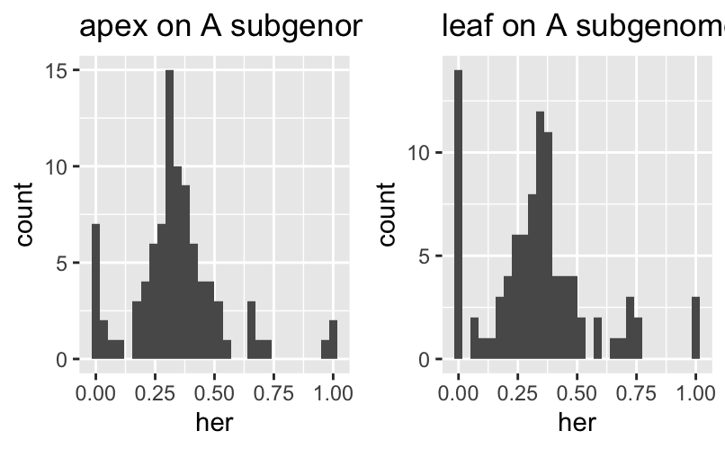

Figure 6: Distribution of Homeolog Expression Ratios in A-Subgenome of Wheat  
Histograms show the distributions of homeolog expression ratios from the A-subgenome of wheat in apex shoot and leaf tissues.

```r
library(ggplot2)
library(gridExtra)

grid.arrange(distr_plots_A[["apex"]] + ggtitle("apex on A subgenome"),
             distr_plots_A[["leaf"]] + ggtitle("leaf on A subgenome"),
             ncol = 2)
```

To calculate HERs from the second or third subgenome, set the `base` option accordingly. For example, to calculate HERs of the second and third subgenomes (i.e., B-subgenome and D-subgenome), set `base = 2` and `base = 3`, respectively.

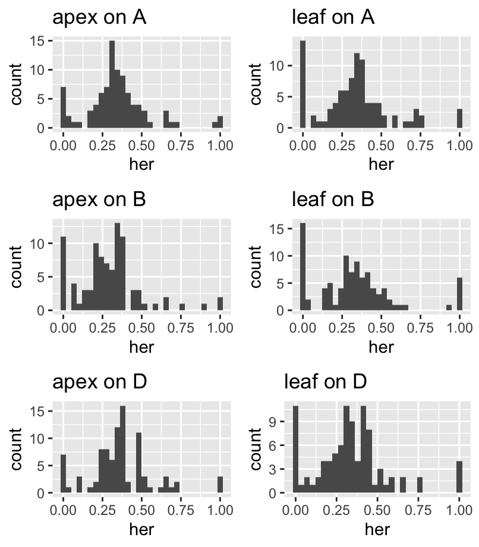

Figure 7: Distribution of Homeolog Expression Ratios Across All Subgenomes  
Histograms display the distributions of homeolog expression ratios for the A, B, and D subgenomes of wheat in apex shoot and leaf tissues.

```r
distr_plots_B <- plot_HER_distr(x, base = 2)
distr_plots_D <- plot_HER_distr(x, base = 3)

grid.arrange(distr_plots_A[["apex"]] + ggtitle("apex on A"), distr_plots_A[["leaf"]] + ggtitle("leaf on A"),
             distr_plots_B[["apex"]] + ggtitle("apex on B"), distr_plots_B[["leaf"]] + ggtitle("leaf on B"),
             distr_plots_D[["apex"]] + ggtitle("apex on D"), distr_plots_D[["leaf"]] + ggtitle("leaf on D"),
             ncol = 2)
```

Histogram peaks at one-third for all subgenomes indicate that most homeologs in wheat are equally expressed from the three subgenomes.

After visually checking HER distributions, use the `hobit()` function to identify homeologs showing significant changes in HERs between shoot apex and leaf tissues.

```r
x_output <- hobit(x)
```

```r
head(x_output)
```

```
##                 gene       pvalue       qvalue   raw_pvalue   raw_qvalue
## 1 TraesCS1A02G122700 1.000000e+00 1.0000000000 1.000000e+00 1.000000e+00
## 2 TraesCS1A02G134600 1.000000e+00 1.0000000000 1.000000e+00 1.000000e+00
## 3 TraesCS1A02G196500 4.675395e-05 0.0007792324 6.455585e-07 1.075931e-05
## 4 TraesCS1A02G218900 1.000000e+00 1.0000000000 1.000000e+00 1.000000e+00
## 5 TraesCS1A02G227600 1.000000e+00 1.0000000000 1.000000e+00 1.000000e+00
## 6 TraesCS1A02G238800 7.514948e-01 1.0000000000 6.647132e-01 9.402695e-01
##        Dmax     ORmax theta__A__apex theta__B__apex theta__D__apex
## 1 0.0403340  1.189864      0.3185115      0.3820635      0.2963890
## 2 0.0445495  1.226520      0.3084100      0.3502945      0.3372370
## 3 0.4579990 45.710227      0.2710425      0.2137675      0.4816680
## 4 0.0534165  1.254953      0.2095590      0.4228765      0.3579005
## 5 0.0488095  1.267277      0.2667100      0.3776580      0.3515555
## 6 0.1127005  1.628395      0.4564800      0.2119505      0.2372625
##   theta__A__leaf theta__B__leaf theta__D__leaf theta0__A theta0__B theta0__D
## 1      0.3417385      0.3419735     0.31285500  0.330340  0.362537 0.3053140
## 2      0.3056240      0.3953775     0.29119550  0.308768  0.373358 0.3153640
## 3      0.4604940      0.5154180     0.01960115  0.367563  0.368861 0.2520745
## 4      0.2063170      0.3772675     0.41281500  0.208914  0.400271 0.3861965
## 5      0.3161010      0.3664105     0.31274250  0.292673  0.372235 0.3333505
## 6      0.5719290      0.1409210     0.26154150  0.516468  0.186341 0.2624760
##    logLik_H1  logLik_H0
## 1 -110.00300 -109.54400
## 2  -87.36515  -86.87730
## 3  -59.17330  -73.32615
## 4 -103.08800 -102.68300
## 5 -108.69550 -108.48000
## 6  -85.70690  -86.03110
```

The output can be sorted in ascending order of *p*-values using the following code.

```r
head(x_output[order(x_output$pvalue), ])
```

```
##                  gene       pvalue       qvalue   raw_pvalue   raw_qvalue
## 31 TraesCS3A02G154900 2.507983e-08 2.507983e-06 1.363680e-11 1.363680e-09
## 15 TraesCS2A02G005100 1.328381e-07 6.641906e-06 1.478017e-10 7.390083e-09
## 73 TraesCS5A02G397600 8.985286e-07 2.995095e-05 2.272360e-09 7.574533e-08
## 68 TraesCS5A02G193900 8.214085e-06 2.053521e-04 5.373794e-08 1.343449e-06
## 55 TraesCS4A02G298400 3.117082e-05 6.234163e-04 3.616102e-07 7.232205e-06
## 3  TraesCS1A02G196500 4.675395e-05 7.792324e-04 6.455585e-07 1.075931e-05
##         Dmax      ORmax theta__A__apex theta__B__apex theta__D__apex
## 31 0.6013935 174.378540      0.2915110      0.2903610      0.2904310
## 15 0.6876410 187.945097      0.2921495      0.2903255      0.2810065
## 73 0.3363475 216.396588      0.2897435      0.2898750      0.2905770
## 68 0.4294740  71.290685      0.2336920      0.0409588      0.7092545
## 55 0.3731488   7.692894      0.1726035      0.4871805      0.3305985
## 3  0.4579990  45.710227      0.2710425      0.2137675      0.4816680
##    theta__A__leaf theta__B__leaf theta__D__leaf theta0__A  theta0__B theta0__D
## 31     0.00250299   0.9001415000    0.096106400 0.1472920 0.59331300 0.1979140
## 15     0.98606400   0.0052328600    0.005892775 0.6372035 0.14949700 0.1457005
## 73     0.35794600   0.0020535050    0.638825500 0.3258085 0.14616800 0.4655295
## 68     0.67100350   0.0006003515    0.327906000 0.4533080 0.02101275 0.5181215
## 55     0.46986350   0.1104350000    0.406142000 0.3245365 0.30032250 0.3705170
## 3      0.46049400   0.5154180000    0.019601150 0.3675630 0.36886100 0.2520745
##    logLik_H1  logLik_H0
## 31 -23.70050  -49.04865
## 15 -14.40510  -37.45770
## 73 -27.89710  -48.07275
## 68 -54.12365  -70.75550
## 55 -93.96520 -108.67450
## 3  -59.17330  -73.32615
```

We then visualize HER changes of the first subgenome between the two tissues. In the visualization, homeologs with *q*-values less than 0.01 are highlighted.

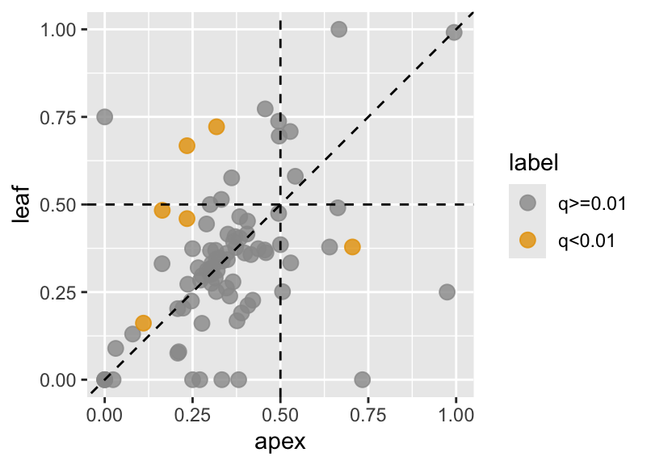

Figure 8: Changes in Homeolog Expression Ratios of the A-Subgenome Between Shoot Apex and Leaf Tissues  
Each point represents the homeolog expression ratio in shoot apex (x-axis) and leaf tissue (y-axis). Orange points indicate homeologs with significant changes in expression ratios between the two tissues, while gray points represent those without significant changes.

```r
is_sig <- ifelse(x_output$qvalue < 0.01, "q<0.01", "q>=0.01")
plot_HER(x, label = is_sig)
```

To switch the base subgenome used for HER calculation, set `base` to the appropriate subgenome number. For example, to use the second subgenome, run the following:

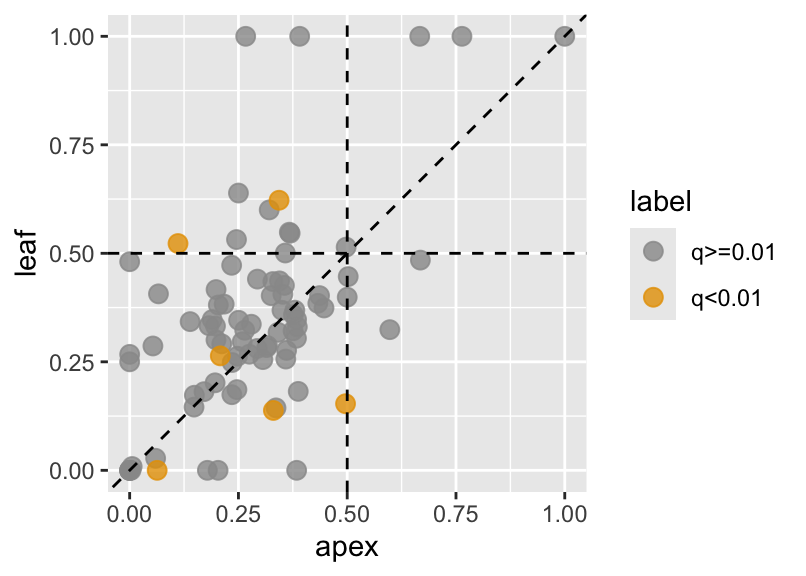

Figure 9: Changes in Homeolog Expression Ratios of the B-Subgenome Between Shoot Apex and Leaf Tissues  
Each point represents the homeolog expression ratio in shoot apex (x-axis) and leaf tissue (y-axis). Orange points indicate homeologs with significant changes in expression ratios between the two tissues, while gray points represent those without significant changes.

```r
plot_HER(x, base = 2, label = is_sig)
```

Note that HER values are calculated for the selected subgenome, while highlighted homeologs are those that meet the significance threshold in any subgenome. As a result, some homeologs may appear highlighted even if they show only minor changes in the plot, since they may have significantly changed HERs in another subgenome.

Additionally, users who wish to test HERs between the combined expression of the A and B subgenomes versus the D subgenome can use the `combine_hexp()` function to merge the homeolog expression values of A and B before conducting the statistical test. Assuming the A and B subgenomes are stored as the first and second subgenomes in the `x` object (as defined in the `mapping_table`), set `subgenomes = c(1, 2)` to combine them:

```r
x_ABvsD <- combine_hexp(x, subgenomes = c(1, 2))
x_ABvsD
```

```
## # 2 subgenomes (D, A+B)
## # 100 homeologs
## ---------------------
## Experiment Design:
##   group
## 1  apex
## 2  apex
## 3  apex
## 4  leaf
## 5  leaf
## 6  leaf
## ---------------------
## > subgenome: D
##            [,1]       [,2]       [,3]       [,4]       [,5]      [,6]
## [1,] 650.915730 751.446812 747.015228 474.708772 433.276269 650.03649
## [2,] 132.169509 128.819454 127.575157 121.884685 126.018261 156.49027
## [3,]   3.055942   2.385545   3.687143   1.603746   9.911549  12.03771
## [4,] 313.998081 191.638817 126.100300 418.577667 560.710466 556.40983
## [5,] 654.735658 793.591448 697.607508 468.293788 489.913690 579.14774
## [6,]  93.970229   0.000000   2.212286  32.074917 109.027035  12.03771
## +++++++++++++++++++++
## > subgenome: A+B
##           [,1]        [,2]         [,3]       [,4]      [,5]       [,6]
## [1,] 1612.0096 1702.484259 1724.1081964 1154.69701 1056.2879 1258.60975
## [2,]  213.1520  277.518452  260.3123154  365.65405  270.4437  350.43119
## [3,]    0.0000    7.156636    1.4748573  418.57767  635.7550  341.06853
## [4,]  548.5417  318.867907  244.0888849  683.19573  713.6315  777.10124
## [5,] 1279.6759 1416.218807 1208.6455662 1060.07601 1189.3858 1143.58271
## [6,]  430.1239    7.156636    0.7374287   68.96107  346.9042   33.43809
## ---------------------
```

Next, HOBIT can be applied to the combined dataset as below.

```r
x_ABvsD_output <- hobit(x_ABvsD)
```

```r
head(x_ABvsD_output[order(x_ABvsD_output$pvalue), ])
```

```
##                  gene       pvalue     qvalue   raw_pvalue   raw_qvalue
## 3  TraesCS1A02G196500 3.993257e-05 0.00250604 9.039789e-07 6.225275e-05
## 15 TraesCS2A02G005100 5.012079e-05 0.00250604 1.245055e-06 6.225275e-05
## 99 TraesCS7A02G452200 9.052840e-04 0.02446725 7.260581e-05 2.024579e-03
## 93 TraesCS7A02G270700 9.786900e-04 0.02446725 8.098318e-05 2.024579e-03
## 41 TraesCS3A02G418300 1.627299e-03 0.03254597 1.649744e-04 3.299488e-03
## 43 TraesCS4A02G006100 4.420865e-03 0.06706910 6.657915e-04 1.078409e-02
##         Dmax      ORmax theta__D__apex theta__A.B__apex theta__D__leaf
## 3  0.4493939  43.484708     0.47588850        0.5241115     0.02012305
## 15 0.4920396 187.761207     0.49997450        0.5000255     0.00569338
## 99 0.4892566  69.830194     0.01671905        0.9832810     0.51456050
## 93 0.3078895   3.866228     0.55155700        0.4484430     0.24066300
## 41 0.2699745   5.828876     0.09001060        0.9099895     0.36310650
## 43 0.4534481  48.829079     0.51415300        0.4858470     0.97851250
##    theta__A.B__leaf theta0__D theta0__A.B logLik_H1 logLik_H0
## 3        0.97987700 0.2491260   0.7508740 -41.29950 -53.29800
## 15       0.99430650 0.2545350   0.7454650 -13.70190 -25.98955
## 99       0.48543950 0.2701580   0.7298420 -10.94970 -19.04870
## 93       0.75933700 0.3980245   0.6019755 -82.25360 -89.83860
## 41       0.63689350 0.2285030   0.7714970 -54.77400 -61.81180
## 43       0.02148785 0.7371965   0.2628035 -12.14275 -18.12190
```

# References

Akama, Satoru, Rie Shimizu-Inatsugi, Kentaro K. Shimizu, and Jun Sese. 2014. “Genome-Wide Quantification of Homeolog Expression Ratio Revealed Nonstochastic Gene Regulation in Synthetic Allopolyploid Arabidopsis.” *Nucleic Acids Research* 42 (6): e46–46. https://doi.org/10.1093/nar/gkt1376.

Akiyama, Reiko, Jianqiang Sun, Masaomi Hatakeyama, Heidi E. L. Lischer, Roman V. Briskine, Angela Hay, Xiangchao Gan, et al. 2021. “Fine-Scale Empirical Data on Niche Divergence and Homeolog Expression Patterns in an Allopolyploid and Its Diploid Progenitor Species.” *New Phytologist* 229(6): 3587–3601. https://doi.org/10.1111/nph.17101.

Robinson, Mark D, and Alicia Oshlack. 2010. “A Scaling Normalization Method for Differential Expression Analysis of RNA-Seq Data.” *Genome Biology* 11(3): R25. https://doi.org/10.1186/gb-2010-11-3-r25.

Sun, Jianqiang, Jun Sese, and Kentaro K. Shimizu. 2025. “A Moderated Statistical Test for Detecting Shifts in Homeolog Expression Ratios in Allopolyploids.” *bioRxiv*. https://doi.org/10.1101/2025.07.01.660977.

Sun, Jianqiang, Rie Shimizu-Inatsugi, Hugo Hofhuis, Kentaro Shimizu, Angela Hay, Kentaro K Shimizu, and Jun Sese. 2020. “A Recently Formed Triploid Cardamine Insueta Inherits Leaf Vivipary and Submergence Tolerance Traits of Parents.” *Frontiers in Genetics* 11: 567262. https://doi.org/10.3389/fgene.2020.567262.

Yang, Yuxin, Xueying Zhang, Lifen Wu, Lichao Zhang, Guoxiang Liu, Chuan Xia, Xu Liu, and Xiuying Kong. 2021. “Transcriptome Profiling of Developing Leaf and Shoot Apices to Reveal the Molecular Mechanism and Co-Expression Genes Responsible for the Wheat Heading Date.” *BMC Genomics* 22(1): 468. https://doi.org/10.1186/s12864-021-07797-7.